# Hotel Bookings

Braden Crimmins, Jaylen Burch, Tanner Burke, Derek Fuller, Daniel Hult

2/15/2021

# Data Cleaning

### General Setup

```r
library(tidyverse)
hotels <- read.csv("hotel_bookings.csv")
```

### Redefining Variable Types

The variables listed below are redefined from integers/characters to factors. The purpose of this is to set each variable up to perform certain analyses.

```r
# Arrival Date Year
hotels$arrival_date_year <- as.factor(hotels$arrival_date_year)
# Arrival Date Month
hotels$arrival_date_month <- as.factor(hotels$arrival_date_month)
# Arrival Date Week Number
hotels$arrival_date_week_number <- as.factor(hotels$arrival_date_week_number)
# Arrival Date Day of Month
hotels$arrival_date_day_of_month <- as.factor(hotels$arrival_date_day_of_month)
# Booking Changes
hotels$booking_changes <- as.factor(hotels$booking_changes)
# Required Car Parking Spaces
hotels$required_car_parking_spaces <- as.factor(hotels$required_car_parking_spaces)
# Total of Special Requests
hotels$total_of_special_requests <- as.factor(hotels$total_of_special_requests)
# Country
hotels$country <- as.factor(hotels$country)
# Meal
hotels$meal <- as.factor(hotels$meal)
# Market Segment
hotels$market_segment <- as.factor(hotels$market_segment)
# Distribution Channel
hotels$distribution_channel <- as.factor(hotels$distribution_channel)
# Customer Type
hotels$customer_type <- as.factor(hotels$customer_type)
# Reservation Status
hotels$reservation_status <- as.factor(hotels$reservation_status)
# Reserved Room Type
hotels$reserved_room_type <- as.factor(hotels$reserved_room_type)
# Assigned Room Type
hotels$assigned_room_type <- as.factor(hotels$assigned_room_type)
# Hotel
hotels$hotel <- as.factor(hotels$hotel)
```

### Creating New Columns

The purpose of creating these new columns is to allow us to perform the necessary analyses.

```r
# Combines bookings with children and bookings with kids as one entity
hotels$kids <- hotels$children + hotels$babies

# Calculates Total Number of Bookings
hotels$totalbookings <- hotels$previous_cancellations + hotels$previous_bookings_not_canceled

# Calculates Proportion of Cancellations to Total Bookings
hotels$propcanceled <- ifelse(hotels$totalbookings != 0, hotels$previous_cancellations/hotels$totalbookings, NA)

# Creates a boolean value to determine if a booking was made by a customer who has booked in the past
hotels$bookedbefore <- as.factor(ifelse(hotels$totalbookings != 0, 1, 0))

# Determines for all customers if they have historically cancelled more than half of their bookings
hotels$cancelled_morethanhalf <- as.factor(ifelse(hotels$propcanceled > 0.5, 1, 0))
```

### Creating New Variables

Determining the total number of cancellations allows us to plot certain variables against total number of cancellations as a means to visually find any correlations in variables to cancellations.

```r
# Total number of cancellations
num_cancel <- sum(hotels$is_canceled)
```

# Customer Analysis

### Bookings by Country

Below is a table and graph showing the number of cancellations made per country.

```
## # A tibble: 10 x 2
##    country num_cancel
##    <fct>        <int>
##  1 PRT          27519
##  2 GBR           2453
##  3 ESP           2177
##  4 FRA           1934
##  5 ITA           1333
##  6 DEU           1218
##  7 IRL            832
##  8 BRA            830
##  9 USA            501
## 10 BEL            474
```

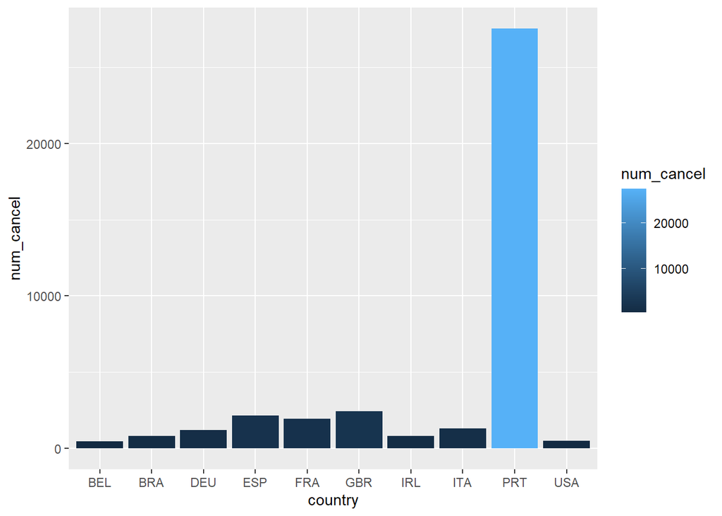

```r
hotels %>% group_by(country) %>% summarise(num_cancel = sum(is_canceled)) %>% arrange(desc(num_cancel)) %>% head(10) %>% print %>% ggplot(aes(x = country, y = num_cancel, fill= num_cancel))+ geom_col()
```

From the data, Portugal is shown to be the country with the most cancellations by a significant amount. However, this is expected given that the hotels from the dataset are located in Portugal, and thus, attract more customers from Portugal than other countries. This chart can double as an indicator of where the customer base for the hotels are located.

### Cancellations Per Booking Method

Below is a bar chart showcasing the number of cancellations made after booking through different distribution channels.

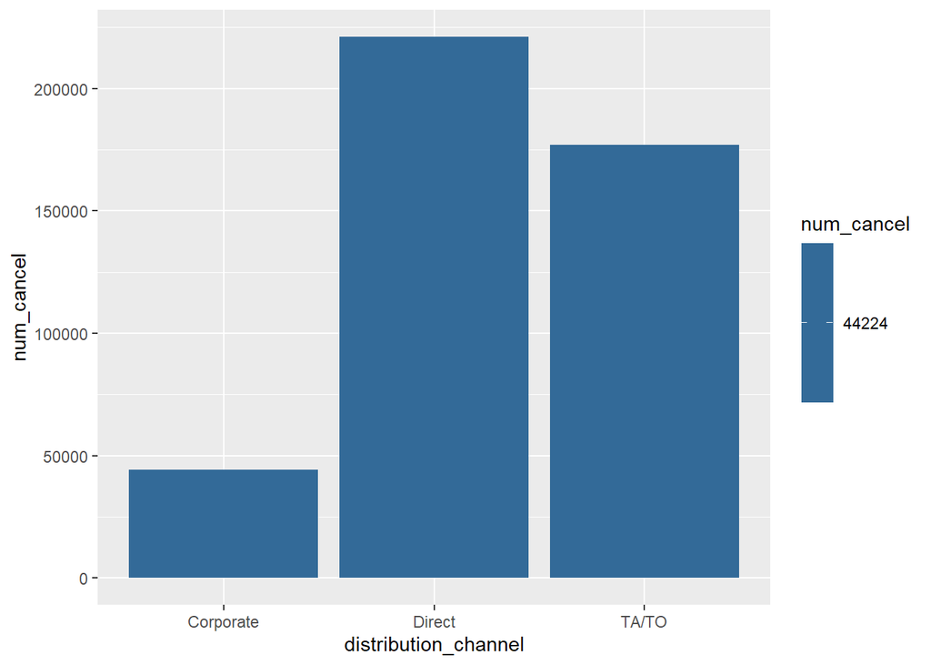

```r
hotels %>% group_by(distribution_channel) %>% arrange(desc(num_cancel)) %>% head(10) %>% ggplot(aes(x = distribution_channel, y = num_cancel, fill = num_cancel)) + geom_col()
```

### Cancellations Per Customer Type

Below is a bar chart showcasing the number of cancellations made for different customer types. Customer Types are categorized by Contract, Group, Transient, and Transient-Party.

###### Contract customers are defined as customers in which the booking has an allotment or other type of contract associated to it.

###### Group customers are defined as customers booking with an associated group.

###### Transient Customers are defined as customers booking as not part of a group or contract, and is not associated with any other transient booking.

###### Transient-Party customers are defined as customers whose booking is transient, but is also associated to at least one other transient booking.

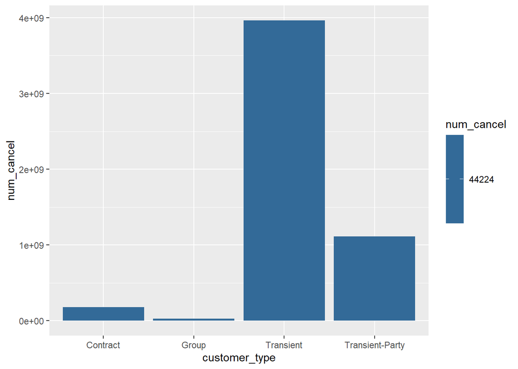

```r
hotels %>% group_by(customer_type) %>%
  arrange(desc(num_cancel)) %>%
  ggplot(aes(x = customer_type, y = num_cancel, fill = num_cancel)) + geom_col()
```

### Reservation Status

Below is a bar chart that shows a comparison between the number of bookings canceled, number of bookings successfully stayed and checked-out, and the number of bookings that resulted in a no-show across the total number of bookings in the data set.

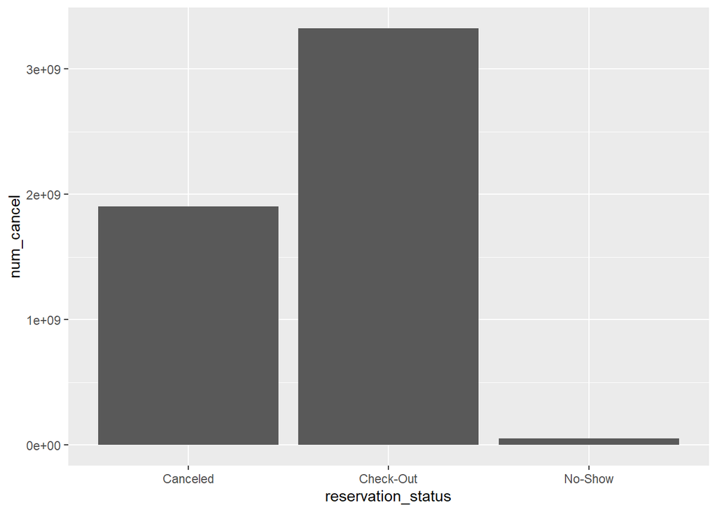

```r
hotels %>% group_by(reservation_status) %>%
  ggplot(aes(x = reservation_status, y = num_cancel)) + geom_col()
```

It can be noted that most of the bookings resulted in a successful check-in and check-out. A substantial number of bookings also resulted in a cancellation. However, this presents a unique opportunity for the company to identify and charge customers higher cancellation fees who are likely to result in a cancellation after booking.

### Cancellations Per Booking Month

Below is a table and bar chart showcasing the number of cancellations made per month from July 2015 to August 2017.

```
## # A tibble: 12 x 2
##    arrival_date_month num_cancel
##    <fct>                   <int>
##  1 August                   5239
##  2 July                     4742
##  3 May                      4677
##  4 June                     4535
##  5 April                    4524
##  6 October                  4246
##  7 September                4116
##  8 March                    3149
##  9 February                 2696
## 10 December                 2371
## 11 November                 2122
## 12 January                  1807
```

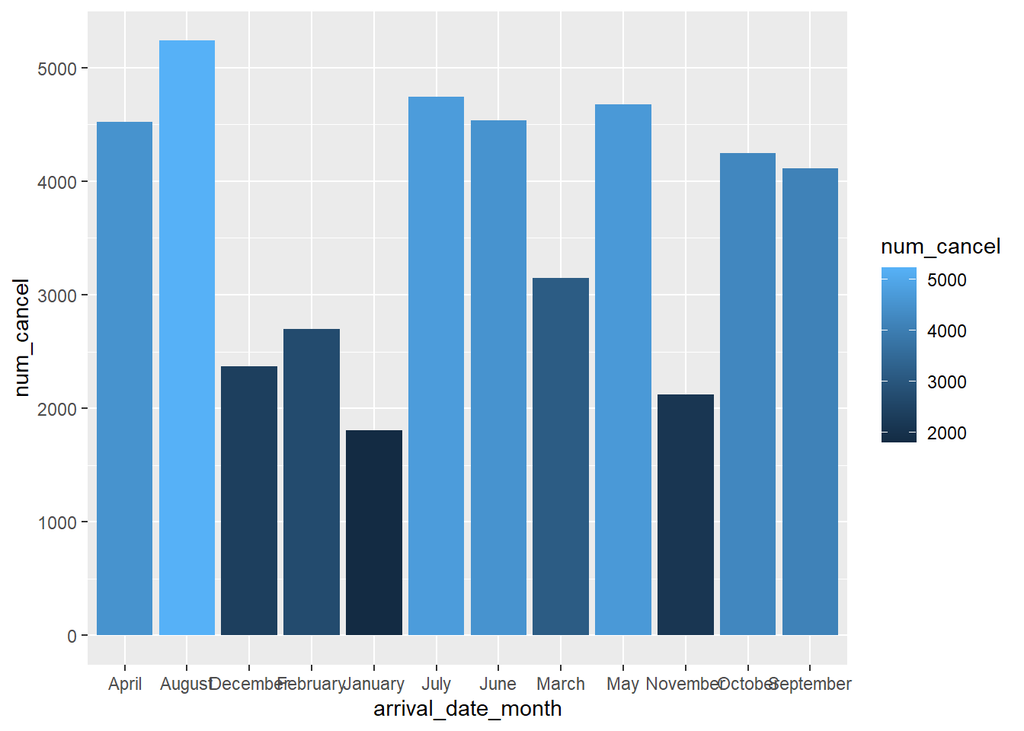

```r
hotels %>% group_by(arrival_date_month) %>% summarise(num_cancel = sum(is_canceled)) %>% arrange(desc(num_cancel)) %>% head(12) %>% print %>% ggplot(aes(x = arrival_date_month, y = num_cancel, fill= num_cancel))+ geom_col()
```

### Children and Cancellations

The table below shows the number of customers who canceled their stay and whether or not they had children booked with them.

```r
hotels %>% select(is_canceled, children) %>%
  na.omit(children) %>%
  mutate(has_child = ifelse(children != 0, 1, 0)) %>%
  group_by(has_child) %>%
  summarise(num_cancel = sum(is_canceled))
```

```
## # A tibble: 2 x 2
##   has_child num_cancel
## *     <dbl>      <int>
## 1         0      41094
## 2         1       3126
```

### Customers with Previous Bookings

```r
table(hotels$bookedbefore)
```

```
##
##      0      1
## 109933   9457
```

```r
round(prop.table(table(hotels$bookedbefore)), 3)
```

```
##
##     0     1
## 0.921 0.079
```

The tables indicate that 92.1% of bookings are made by first-time customers whereas 7.9% of bookings are made by returning customers.

Below are two tables showing the cancellation rates of returning customers - customers who have booked before at the hotel. The first table showcases the cancellation rate for first-time customers and the second table showcases the cancellation rate for returning customers. 0 represents customers who successfully checked-in to their booking and 1 represents customers who canceled their booking.

```r
round(prop.table(table(hotels$is_canceled[hotels$bookedbefore == 0])), 2)
```

```
##
##    0    1
## 0.65 0.35
```

```r
round(prop.table(table(hotels$is_canceled[hotels$bookedbefore == 1])), 2)
```

```
##
##    0    1
## 0.36 0.64
```

The tables indicate that first-time customers have a lower cancellation rate (35%) than returning customers (64%). Therefore, if a customer has booked before, they are much more likely to cancel. 1/3 of first-time customers are likely to cancel whereas 2/3 of repeat customers are likely to cancel.

Below are two tables showing the cancellation rate of (1) returning customers who have canceled previous bookings fewer than half of the time, and (2) returning customers who have canceled more than half previous bookings. 0 represents customers who successfully checked-in to their booking and 1 represents customers who canceled their booking.

```r
round(prop.table(table(hotels$is_canceled[hotels$cancelled_morethanhalf == 0])), 2)
```

```
##
##    0    1
## 0.95 0.05
```

```r
round(prop.table(table(hotels$is_canceled[hotels$cancelled_morethanhalf == 1])), 2)
```

```
##
##    0    1
## 0.01 0.99
```

```r
# IF a customer has NOT canceled more than half of their bookings, then they will almost certainly check-in/come. IF a customer HAS canceled more than half of their bookings, then they will almost certainly cancel again.
```

The tables indicate that customers who have not canceled more than half of their previous bookings are substantially less likely to cancel their next booking (5%) than customers who have canceled more than half of their previous bookings (99%). Ultimately, if a customer has not canceled more than half of their bookings, then they will almost certainly check-in. If a customer has canceled more than half of their bookings, then they will almost certainly cancel again.

Below is a boxplot and two tables showcasing the cancellation likelihood of customers based on their historical cancellation rates.

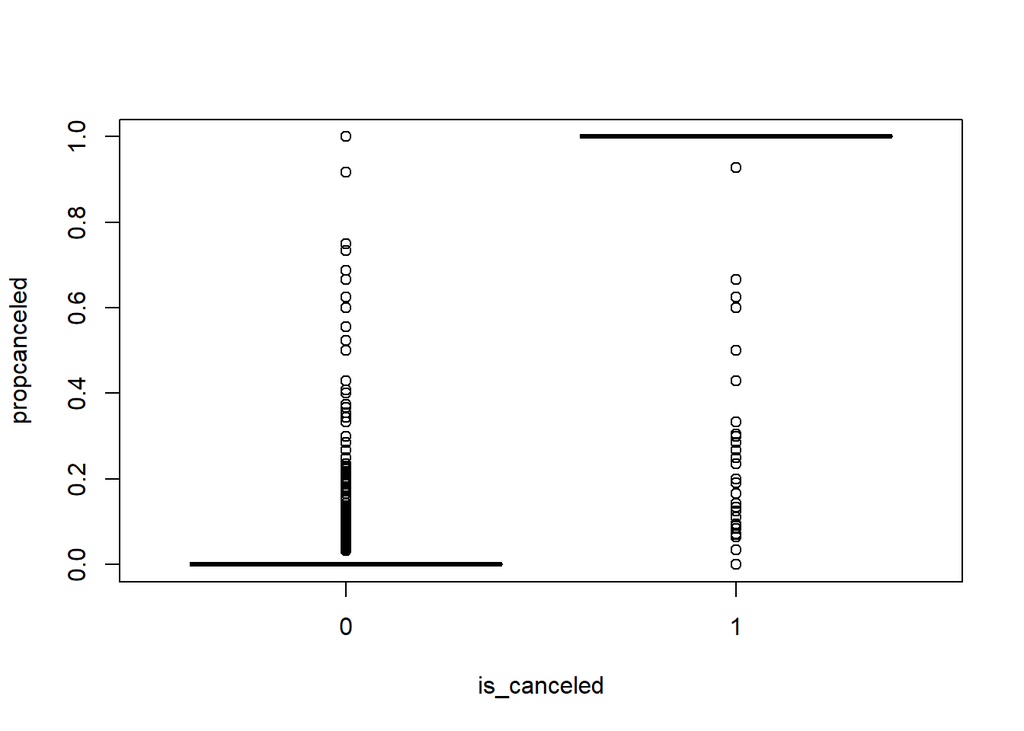

```r
boxplot(propcanceled ~ is_canceled, data = hotels, na.rm = TRUE)
```

```r
table(hotels$is_canceled[!is.na(hotels$propcanceled)], hotels$cancelled_morethanhalf[!is.na(hotels$propcanceled)])
```

```
##
##        0    1
##   0 3397   48
##   1  178 5834
```

```r
round(prop.table(table(hotels$is_canceled[!is.na(hotels$propcanceled)], hotels$cancelled_morethanhalf[!is.na(hotels$propcanceled)])), 3)
```

```
##
##         0     1
##   0 0.359 0.005
##   1 0.019 0.617
```

Only 1/3 of reservations by people who have made reservations before are made my people who have a history of showing up more than half the time. These people consistently show up and check in to their stay. The remaining 2/3 of reservations are made by people who have a history of canceling. These people consistently book a reservation and then, ultimately, cancel that reservation.

# Conclusion